# Stat 579 - Homework #2 - section B

9/10/2019

## Homework #2

For this homework we are using the data set `earthquakes` from the classdata package. `earthquake` contains data on every earthquake and earthquake-like event recorded by the USGS (United States Geological Survey) since Jan 1 2019.

Run the following two commands to install the newest version of the package from github:

```r
library(devtools) # error? then run install.packages("devtools")
devtools::install_github("heike/classdata")
```

Check what is in the data set:

```r
library(classdata)
head(earthquakes)
```

```
##                  time  latitude longitude depth  mag magType nst gap
## 1 2019-09-02 16:35:27 -14.02970  -72.6001 80.00 5.00      mb  NA  73
## 2 2019-09-02 16:24:37  19.41983 -155.2735 -0.04 2.61      ml  44  44
## 3 2019-09-02 16:23:50  19.16200 -155.4593 32.07 3.61      ml  16 245
## 4 2019-09-02 15:46:36  39.23480   40.1384 10.00 4.30      mb  NA  64
## 5 2019-09-02 13:02:45  80.06390   -0.6557 10.00 5.20      mb  NA  45
## 6 2019-09-02 09:57:19  58.39270 -152.7506 39.30 2.50      ml  NA  NA
##       dmin  rms net           id                  updated
## 1 4.605000 1.03  us   us70005b70 2019-09-02T17:10:21.040Z
## 2 0.006234 0.20  hv   hv71121642 2019-09-02T16:52:18.257Z
## 3 0.095160 0.16  hv   hv71121637 2019-09-02T16:29:33.590Z
## 4 0.829000 0.80  us   us70005b6p 2019-09-02T16:41:46.040Z
## 5 2.578000 1.09  us   us70005b6f 2019-09-02T13:34:33.040Z
## 6       NA 0.59  ak ak019b9cd6s8 2019-09-02T13:55:17.040Z
##                        place       type horizontalError depthError
## 1   53km SE of Abancay, Peru earthquake            8.00       1.90
## 2 3km WSW of Volcano, Hawaii earthquake            0.17       0.15
## 3  5km SSE of Pahala, Hawaii earthquake            1.14       1.05
## 4 6km E of Yayladere, Turkey earthquake            2.90       1.90
## 5          North of Svalbard earthquake            7.30       1.40
## 6 70km NNW of Kodiak, Alaska earthquake              NA       1.30
##   magError magNst    status locationSource magSource
## 1    0.030    352  reviewed             us        us
## 2    0.440     27 automatic             hv        hv
## 3    0.680     19 automatic             hv        hv
## 4    0.188      8  reviewed             us        us
## 5    0.026    505  reviewed             us        us
## 6       NA     NA automatic             ak        ak
```

3. Answer the following questions (and show your code): how many events were recorded in total? how many of those events are earthquakes? How many of the variables have the word `error` in their name? What is the average magnitude of the observed events?

```r
summary(earthquakes)
```

```
##       time                        latitude         longitude
##  Min.   :2019-01-01 00:04:05   Min.   :-65.607   Min.   :-180.00
##  1st Qu.:2019-03-05 11:08:06   1st Qu.: -2.697   1st Qu.:-134.13
##  Median :2019-05-10 17:24:51   Median : 22.347   Median : -75.09
##  Mean   :2019-05-05 01:13:48   Mean   : 20.269   Mean   : -36.83
##  3rd Qu.:2019-07-06 09:21:17   3rd Qu.: 38.875   3rd Qu.: 116.29
##  Max.   :2019-09-02 16:35:27   Max.   : 86.601   Max.   : 180.00
##
##      depth             mag          magType               nst
##  Min.   : -3.41   Min.   :2.500   Length:16414       Min.   :  2.00
##  1st Qu.: 10.00   1st Qu.:2.890   Class :character   1st Qu.: 11.00
##  Median : 12.80   Median :4.100   Mode  :character   Median : 24.00
##  Mean   : 61.05   Mean   :3.793                      Mean   : 30.21
##  3rd Qu.: 59.00   3rd Qu.:4.500                      3rd Qu.: 41.00
##  Max.   :667.39   Max.   :8.000                      Max.   :221.00
##                                                      NA's   :11737
##       gap             dmin             rms              net
##  Min.   : 10.0   Min.   : 0.000   Min.   : 0.0100   Length:16414
##  1st Qu.: 66.0   1st Qu.: 0.326   1st Qu.: 0.3100   Class :character
##  Median :108.0   Median : 1.265   Median : 0.6200   Mode  :character
##  Mean   :127.4   Mean   : 2.364   Mean   : 0.6131
##  3rd Qu.:174.0   3rd Qu.: 2.918   3rd Qu.: 0.8500
##  Max.   :358.0   Max.   :48.903   Max.   :46.2400
##  NA's   :1459    NA's   :1521
##       id              updated             place
##  Length:16414       Length:16414       Length:16414
##  Class :character   Class :character   Class :character
##  Mode  :character   Mode  :character   Mode  :character
##
##
##
##
##                type       horizontalError    depthError
##  earthquake      :16282   Min.   : 0.080   Min.   :    0.000
##  explosion       :    3   1st Qu.: 2.300   1st Qu.:    1.140
##  ice quake       :    3   Median : 6.430   Median :    2.000
##  mine collapse   :    1   Mean   : 6.308   Mean   :    5.801
##  mining explosion:  115   3rd Qu.: 9.300   3rd Qu.:    6.900
##  other event     :    9   Max.   :99.000   Max.   :20014.600
##  quarry blast    :    1   NA's   :1605
##     magError          magNst             status      locationSource
##  Min.   :0.0000   Min.   :  0.00   automatic: 1203   Length:16414
##  1st Qu.:0.0800   1st Qu.: 11.00   reviewed :15211   Class :character
##  Median :0.1270   Median : 22.00                     Mode  :character
##  Mean   :0.1446   Mean   : 37.48
##  3rd Qu.:0.1760   3rd Qu.: 39.00
##  Max.   :4.7500   Max.   :666.00
##  NA's   :1982     NA's   :1771
##    magSource
##  us     :9937
##  ci     :2304
##  ak     :1735
##  pr     :1532
##  nc     : 341
##  hv     : 220
##  (Other): 345
```

```r
dim(earthquakes)
```

```
## [1] 16414    22
```

16414 events in total were recorded. 16282 of them were earthquakes. Three variables have the word error in their name. The average magnitude is 3.793.

4. On July 12, residents of Seattle were rudely awakened by an earthqake of a magnitude of 4.6. What proportion of earthquakes in the data are (roughly) even bigger than the July 12 earthquake in Seattle? Show your code.

```r
summary(earthquakes$mag)
```

```
##    Min. 1st Qu.  Median    Mean 3rd Qu.    Max.
##   2.500   2.890   4.100   3.793   4.500   8.000
```

approximately 25% of the earthquakes are stronger than 4.6

5. Visualize the observed geographic location of the events. Extra point for using `ggplot2`.

```r
summary(earthquakes$latitude)
```

```
##    Min. 1st Qu.  Median    Mean 3rd Qu.    Max.
## -65.607  -2.697  22.347  20.269  38.875  86.601
```

```r
summary(earthquakes$longitude)
```

```
##    Min. 1st Qu.  Median    Mean 3rd Qu.    Max.
## -180.00 -134.13  -75.09  -36.83  116.29  180.00
```

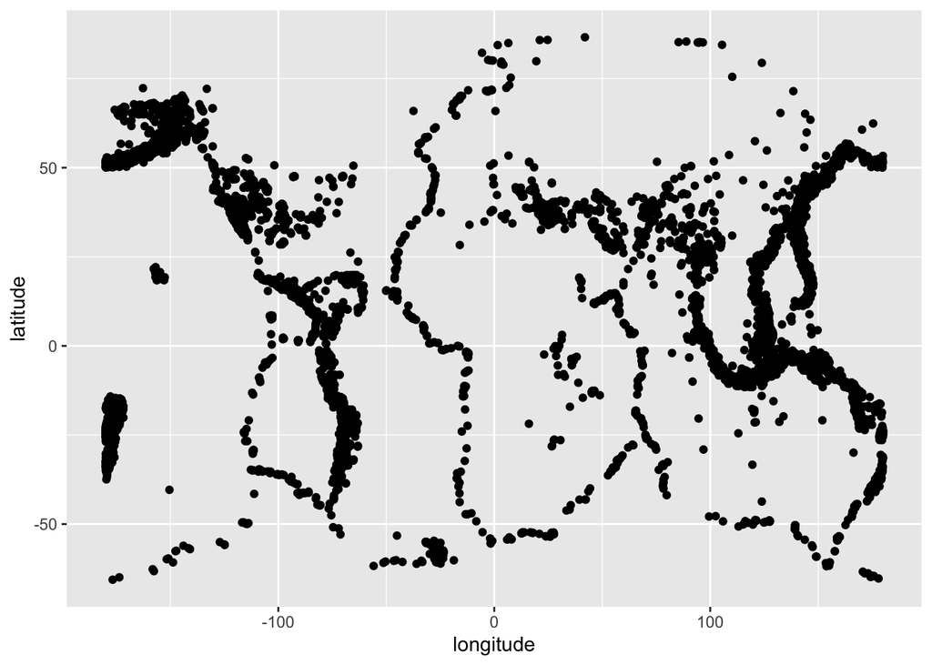

```r
library(ggplot2)
ggplot(data = earthquakes, aes(x = longitude, y = latitude))+
  geom_point()
```

Due date: the homework is due a week from now on Tuesday

For the submission: submit your solution in an R Markdown file and (just for insurance) submit the corresponding html/word file with it.